# Unsupervised learning

# Unsupervised learning

- 자료에 outcome (or response) measurement가 포함되지 않은 경우
- 군집분석, 밀도함수추정, 차원축소 등을 통칭

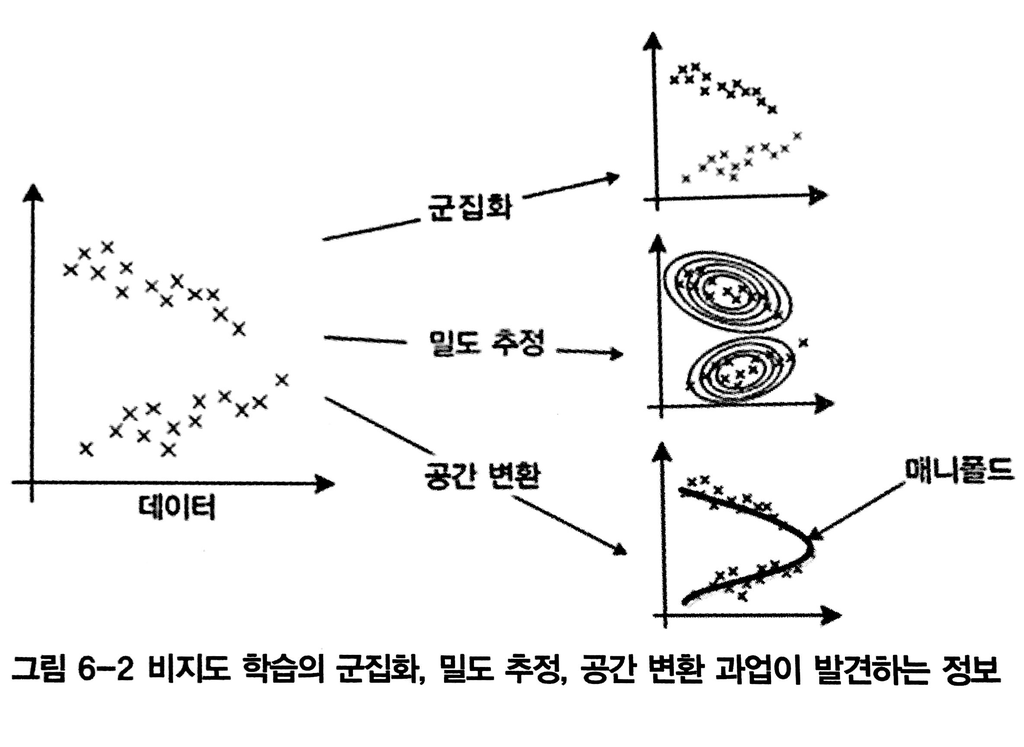

## 1. Clustering

- 군집분석은 데이터 세트에서 sub-group, 또는 군(cluster)을 찾기 위한 기술임
- 군집분석이 잘 되었다면 각 그룹 내에서 성질이 유사하지만 그룹 간 성질이 매우 다름
- 군집분석 방법의 종류는 다양함
- 가장 일반적으로 쓰이고 있는 2가지 접근법
  - **K-평균 군집분석** (K-Means Clustering)
  - **계층적 군집분석** (Hierarchical Clustering)

### 1.1 유사성 측도

- 기본적으로 관측치 간의 유사성에 의해 군집을 형성하기 때문에 유사성(similarity)을 측정하기 위한 적절한 거리 측도가 필요
  - Euclidean: quantitative 데이터에 사용
    $$d(x, y) = \sqrt{\sum_{j=1}^d(x_j - y_j)^2}$$
  - Hamming distance (number of mismatches): categorical 데이터에 사용
    $$d(x, y) = \sum_{j=1}^d I(x_j \neq y_j)$$
  - Manhattan (city block) distance: quantitative 데이터에 사용
    $$d(x, y) = \sum_{j=1}^d |x_j - y_j|$$

### 1.2 K-평균 군집분석 K-means clustering

#### K-means 알고리즘

- 관측데이터를 $\{x_i,\,i=1,2,...,n\}$로, 군집집합을 $\{c_1, c_2,...,c_k\}$으로 나타내기로 하자.
1. $K$개의 군집중심 $\{z_k,\,k=1,2,...,K\}$을 초기화
2. $x_i$ ($i=1,2,...,n$) 를 가장 가까운 군집중심에 해당하는 군집에 배정
3. 직전 군집 배정 결과와 달라진 것이 없으면 멈춤
4. 군집별 데이터 평균으로 $z_k$를 대체 ($k=1,2,...,K$)
5. 2로 이동
- 위 알고리즘은 손실함수
  $$\sum_{i=1}^n \sum_{k=1}^K I(x_i\in c_k)d(x_i, z_k)$$
  를 최소로 하는 것을 목적으로 학습을 실시하는 것과 동일한 것이며, 반드시 수렴한다는 것이 밝혀져 있음
- 다만, 단계 1의 초기 군집중심을 어떻게 정하느냐에 따라 최종 결과가 달라지는 문제가 있음
- 이 문제를 피하기 위해 서로 다른 초기 군집중심을 가지고 여러 번 $K$-means 알고리즘을 수행한 다음 가장 좋은 품질의 결과를 선택하는데 이를 다중 시작 알고리즘이라 한다.

#### 예제: 모의실험 데이터

- 데이터 생성

```r
set.seed(0)
x <- rbind(matrix(rnorm(100, sd = 0.3), ncol = 2),
           matrix(rnorm(100, mean = 1, sd = 0.3), ncol = 2))
colnames(x) <- c("x", "y")
```

- 클러스터링

```r
cl <- kmeans(x, 2)
```

- 결과 확인

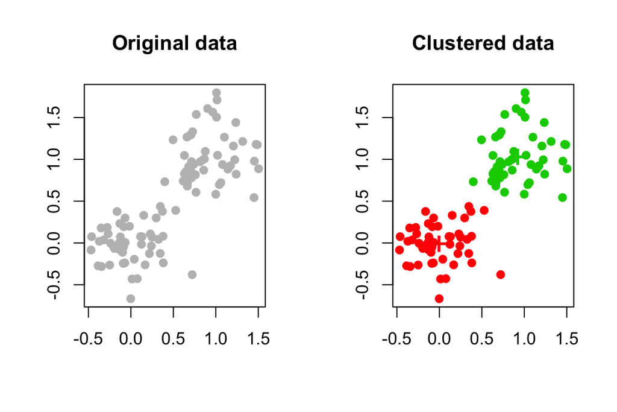

```r
par(mfrow = c(1, 2))
plot(x, xlab = "", ylab = "", col = "gray", pch = 19,
     main = "Original data")
color <- cl$cluster + 1
plot(x, xlab = "", ylab = "", col = color, pch = 19,
     main = "Clustered data")
points(cl$centers, col = 2:3, pch = "+", cex = 2)
```

#### 예제 데이터 분석: `protein`

- Data

```r
protein <- read.table("./dat/protein.txt", sep = "\t", header = TRUE)
summary(protein)
```

```
##            Country      RedMeat         WhiteMeat           Eggs
##  Albania       : 1   Min.   : 4.400   Min.   : 1.400   Min.   :0.500
##  Austria       : 1   1st Qu.: 7.800   1st Qu.: 4.900   1st Qu.:2.700
##  Belgium       : 1   Median : 9.500   Median : 7.800   Median :2.900
##  Bulgaria      : 1   Mean   : 9.828   Mean   : 7.896   Mean   :2.936
##  Czechoslovakia: 1   3rd Qu.:10.600   3rd Qu.:10.800   3rd Qu.:3.700
##  Denmark       : 1   Max.   :18.000   Max.   :14.000   Max.   :4.700
##  (Other)       :19
##       Milk            Fish           Cereals          Starch
##  Min.   : 4.90   Min.   : 0.200   Min.   :18.60   Min.   :0.600
##  1st Qu.:11.10   1st Qu.: 2.100   1st Qu.:24.30   1st Qu.:3.100
##  Median :17.60   Median : 3.400   Median :28.00   Median :4.700
##  Mean   :17.11   Mean   : 4.284   Mean   :32.25   Mean   :4.276
##  3rd Qu.:23.30   3rd Qu.: 5.800   3rd Qu.:40.10   3rd Qu.:5.700
##  Max.   :33.70   Max.   :14.200   Max.   :56.70   Max.   :6.500
##
##       Nuts           Fr.Veg
##  Min.   :0.700   Min.   :1.400
##  1st Qu.:1.500   1st Qu.:2.900
##  Median :2.400   Median :3.800
##  Mean   :3.072   Mean   :4.136
##  3rd Qu.:4.700   3rd Qu.:4.900
##  Max.   :7.800   Max.   :7.900
##
```

- 분석에 사용할 변수 지정 및 scaling

```r
vars.to.use <- colnames(protein)[-1]
pmat <- scale(protein[,vars.to.use])
```

- K-means 군집법 적용 ($K=5$)

```r
pKmeans <- kmeans(pmat, 5)
```

- 분석 결과 출력

```r
print.clusters <- function(labels, k) {
  for(i in 1:k) {
    print(paste("cluster", i))
    print(protein[labels == i, c("Country","RedMeat","Fish","Fr.Veg")])
  }
}

print.clusters(pKmeans$cluster, 5)
```

```
## [1] "cluster 1"
##           Country RedMeat Fish Fr.Veg
## 5  Czechoslovakia     9.7  2.0    4.0
## 7       E Germany     8.4  5.4    3.6
## 11        Hungary     5.3  0.3    4.2
## 16         Poland     6.9  3.0    6.6
## 23           USSR     9.3  3.0    2.9
## [1] "cluster 2"
##       Country RedMeat Fish Fr.Veg
## 1     Albania    10.1  0.2    1.7
## 4    Bulgaria     7.8  1.2    4.2
## 10     Greece    10.2  5.9    6.5
## 13      Italy     9.0  3.4    6.7
## 18    Romania     6.2  1.0    2.8
## 25 Yugoslavia     4.4  0.6    3.2
```

[output cut: 20 more lines]

### 1.3 계층적 군집 알고리즘 Hierarchical clustering

- 군집에 hierarchy를 부여하는 방식으로 dendrogram을 그려볼 수 있는 장점이 있음

#### 예제 데이터 분석: `protein`

- 학습

```r
d <- dist(pmat, method = "euclidean") # Euclidean distances
pfit <- hclust(d, method = "ward.D2")
```

- 학습 결과를 dendrogram으로 시각화

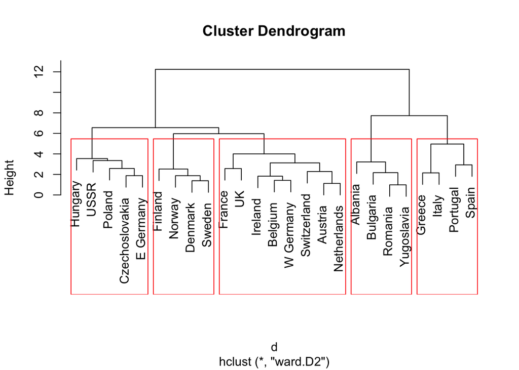

```r
plot(pfit, labels = protein$Country)
rect.hclust(pfit, k = 5)
```

## 2. Density estimation

### 2.1 Parametric

- 데이터가 생성된 분포를 아는 것이 추론의 궁극적인 목표임
- 모수적 모형: 모수의 값에 의해 분포의 특성이 완전히 결정되는 모형. 따라서 모수값을 알아내는(추정하는) 것이 데이터가 생성되는 메커니즘을 이해하는 것이 됨.
  - (c.f.) 비모수적 모형
- Maximum likelihood estimation
  - $x_1,x_2,...,x_n$을 밀도함수가 $f(x|\theta)$인 분포에서 추출된 데이터라 하면 likelihood 함수는 다음과 같이 정의
    $$L(\theta|x_1,...,x_n) = \prod_{i=1}^n f(x_i|\theta)$$
  - $L(\theta|x_1,...,x_n)$ 또는 $\log L(\theta|x_1,...,x_n)$를 최대로 하는 $\theta$를 찾음: MLE, maximum likelihood estimation

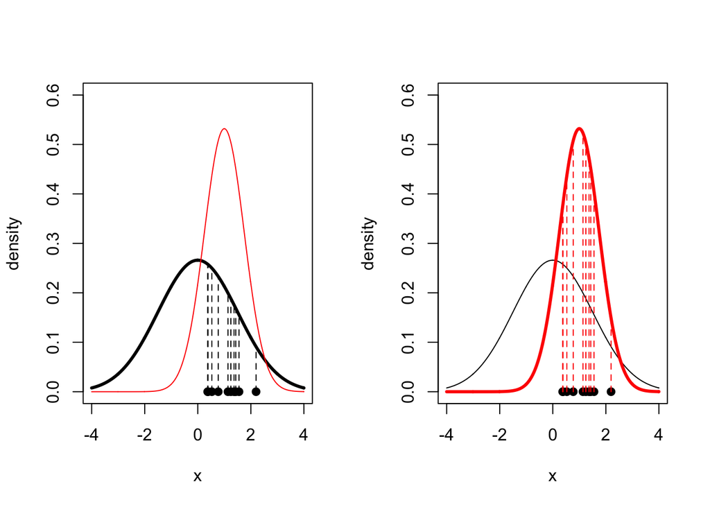

### 2.2 Nonparametric: Kernel smoothing

- 분포함수의 형태를 모수적으로 결정할 정보가 없을 때, 또는 데이터의 분포를 탐색적으로 살펴볼 때 사용하는 모델링
- 커널 평활법이 가장 널리 사용되고 있음
  - 히스토그램을 스무딩한 것으로 이해 가능
  - $x_1, ..., x_n$가 밀도함수가 $f(x)$인 분포에서 추출된 데이터라 할 때,
    $$\hat f (x) = \frac{1}{nh}\sum_{i=1}^n K \left(\frac{x_i - x}{h}\right)$$
    단, $K$는 커널 함수, $h$는 평활량(bandwidth).
  - $K$보다는 $h$의 선택이 훨씬 중요

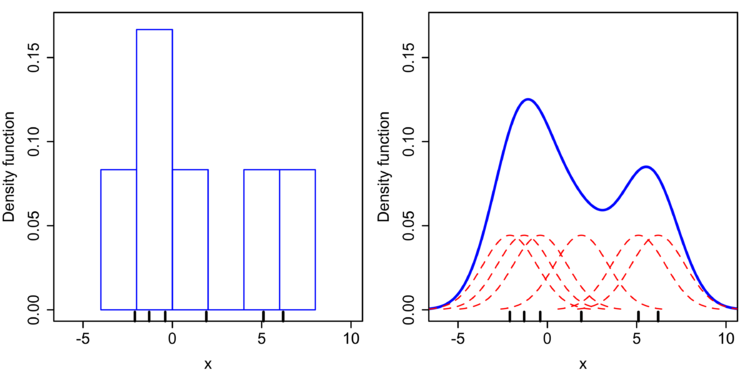

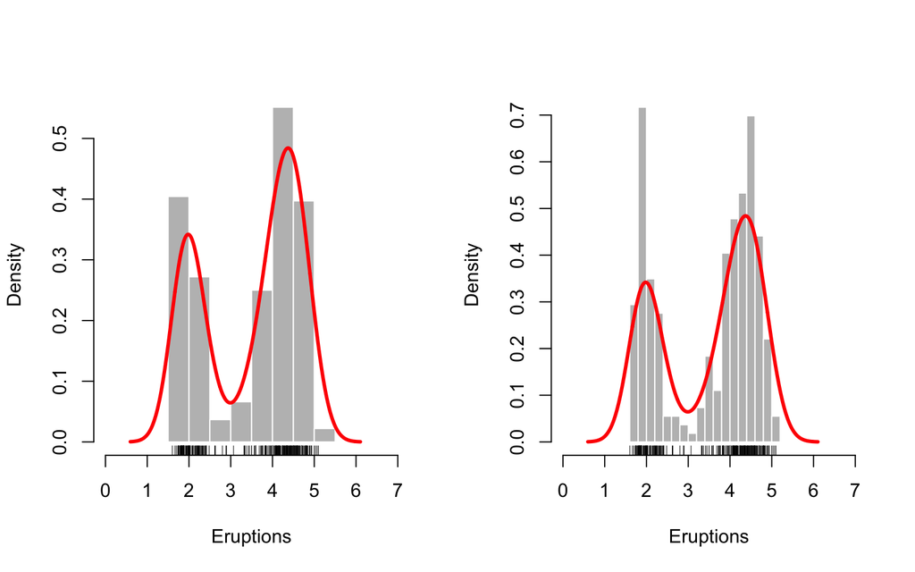

```r
data(faithful)

par(mfrow = c(1, 2))

hist(faithful$eruptions, probability = TRUE,
     xlim = c(0, 7), main = "", col = "gray", border = "white", xlab = "Eruptions")
rug(faithful$eruptions)
lines(density(faithful$eruptions), col = 2, lwd = 3)

hist(faithful$eruptions, probability = TRUE, nclass = 20,
     xlim = c(0, 7), main = "", col = "gray", border = "white", xlab = "Eruptions")
rug(faithful$eruptions)
lines(density(faithful$eruptions), col = 2, lwd = 3)
```

## 3. Dimension reduction

### 3.1 Principal Component Analysis, PCA

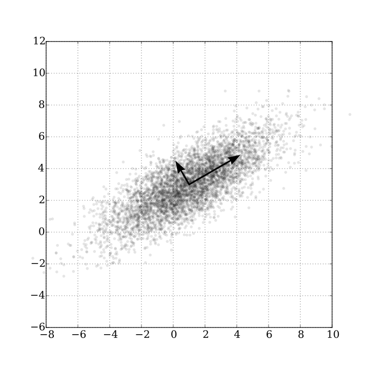

- Feature들을 합성해 데이터의 변동을 잘 설명할 수 있는 방향에 해당하는 몇 개의 새로운 변수(주성분)를 만들어내는 방법
  - 차원 축소 효과
  - 기본적으로 데이터의 분포의 변이 정보만 활용하는 비모수적 방법이기 때문에 활용성이 매우 높음
- PCA는 feature들을 합성해 데이터의 변동을 잘 설명할 수 있는 방향에 해당하는 몇 개의 새로운 변수(주성분)를 만들어내는 방법이다.

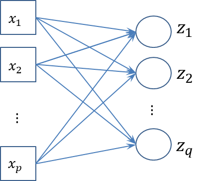

- 차원 축소 효과가 확실하고 기본적으로 데이터의 분포의 변이 정보만 활용하는 비모수적 방법이기 때문에 활용성이 매우 높음
- $N\times J$인 데이터 행렬 $X$의 분산공분산행렬 $\Sigma$에 대해 spectral decomposition을 실시 ($N > J$)
  $$\Sigma = P \Lambda P^\top = \sum_{j=1}^J \lambda_j p_j p_j^\top$$
  - 단, $P = [p_1, p_2,...,p_J]$는 $\Sigma$의 고유벡터들로 구성된 행렬이고 $\lambda_j$($\lambda_1\ge \lambda_2\ge...$을 가정)는 고유벡터 $p_j$에 대응되는 고유값이다. 이 때 고유벡터 $p_j$들이 주성분이 된다.
- 데이터의 공분산 구조를 이용하기 때문에 feature별 단위가 다른 경우 사용에 주의할 필요가 있음
  - 표준화 후 PCA 알고리즘을 적용하는 것이 바람직함

#### 예제 데이터 분석: `state.x77`

- 데이터 정보 확인 및 표준화

```r
summary(state.x77)
```

```
##    Population        Income       Illiteracy       Life Exp
##  Min.   :  365   Min.   :3098   Min.   :0.500   Min.   :67.96
##  1st Qu.: 1080   1st Qu.:3993   1st Qu.:0.625   1st Qu.:70.12
##  Median : 2838   Median :4519   Median :0.950   Median :70.67
##  Mean   : 4246   Mean   :4436   Mean   :1.170   Mean   :70.88
##  3rd Qu.: 4968   3rd Qu.:4814   3rd Qu.:1.575   3rd Qu.:71.89
##  Max.   :21198   Max.   :6315   Max.   :2.800   Max.   :73.60
##      Murder          HS Grad          Frost             Area
##  Min.   : 1.400   Min.   :37.80   Min.   :  0.00   Min.   :  1049
##  1st Qu.: 4.350   1st Qu.:48.05   1st Qu.: 66.25   1st Qu.: 36985
##  Median : 6.850   Median :53.25   Median :114.50   Median : 54277
##  Mean   : 7.378   Mean   :53.11   Mean   :104.46   Mean   : 70736
##  3rd Qu.:10.675   3rd Qu.:59.15   3rd Qu.:139.75   3rd Qu.: 81162
##  Max.   :15.100   Max.   :67.30   Max.   :188.00   Max.   :566432
```

```r
dat <- scale(state.x77[, 2:6])
```

- 학습

```r
PC <- princomp(dat)
summary(PC)
```

```
## Importance of components:
##                           Comp.1    Comp.2     Comp.3     Comp.4
## Standard deviation     1.7712453 0.9588344 0.62532463 0.55002370
## Proportion of Variance 0.6402673 0.1876252 0.07980222 0.06174001
## Cumulative Proportion  0.6402673 0.8278925 0.90769473 0.96943474
##                            Comp.5
## Standard deviation     0.38700098
## Proportion of Variance 0.03056526
## Cumulative Proportion  1.00000000
```

```r
loadings(PC)
```

```
##
## Loadings:
##            Comp.1 Comp.2 Comp.3 Comp.4 Comp.5
## Income      0.347  0.732  0.258  0.524
## Illiteracy -0.480         0.739 -0.187  0.428
## Life Exp    0.469 -0.324  0.616 -0.105 -0.533
## Murder     -0.459  0.492        -0.297 -0.677
## HS Grad     0.467  0.336        -0.769  0.268
##
##                Comp.1 Comp.2 Comp.3 Comp.4 Comp.5
## SS loadings       1.0    1.0    1.0    1.0    1.0
## Proportion Var    0.2    0.2    0.2    0.2    0.2
## Cumulative Var    0.2    0.4    0.6    0.8    1.0
```

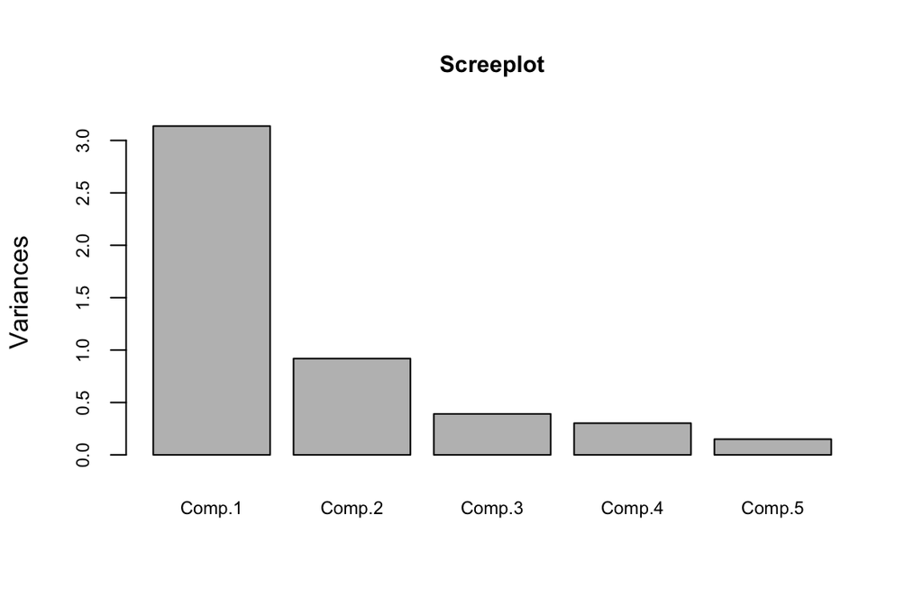

```r
plot(PC, main = "Screeplot", cex.main = 0.9, cex.axis = 0.7, cex = 0.7)
```

```r
PC$scores[1:7, ]
```

```
##                 Comp.1     Comp.2      Comp.3      Comp.4     Comp.5
## Alabama     -3.4736429  0.1178291 0.002067821 -0.33202297 -0.5014985
## Alaska       0.5523458  3.7421172 0.308375193  0.01581157  0.7537270
## Arizona     -0.3218179  0.5272740 0.601919030 -0.59584526  0.6692075
## Arkansas    -2.3518240 -1.3110142 0.447120711 -0.07107168 -0.4328275
## California   0.9138319  1.3829544 0.468124431 -0.60393459 -0.5394775
## Colorado     1.7319349  0.5670988 0.061375353 -0.54694216 -0.2946209
## Connecticut  1.8293070  0.2417523 1.038122264  0.74326461  0.2763367
```

- 학습된 주성분을 시각화

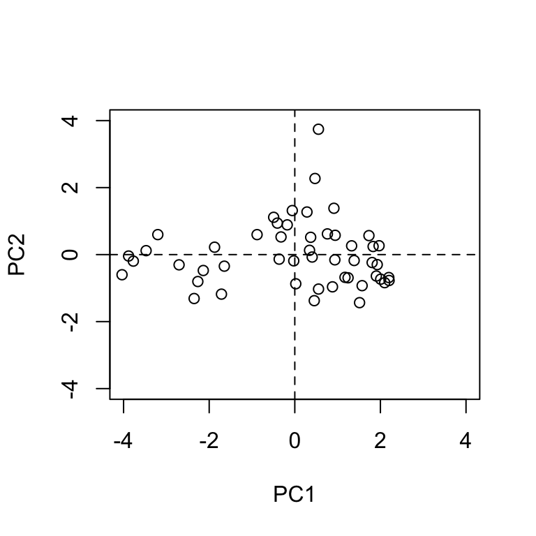

```r
plot(PC$scores[,1:2], xlab = "PC1", ylab = "PC2",
     xlim = c(-4, 4), ylim = c(-4, 4))
abline(h = 0, lty = 2)
abline(v = 0, lty = 2)
```

### 3.2 요인분석 FA, factor analysis

- Feature를 합성하는 PCA와 달리, FA는 feature를 발현시키는 몇 개의 잠재요인(latent factor)이 있다고 가정하고 그 잠재요인을 찾는 방법
- 즉, 각 feature가 잠재요인들의 선형결합으로 구성되었다고 가정한다.

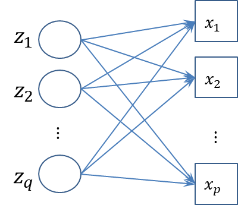

- $X = (X_1,X_2,...,X_p)^\top\sim \cdot(0_p,\Sigma)$일 때,
  $$X = LF + \epsilon \quad(p \ge m)$$
  로 분해
  - 공통 잠재인자 $F$는
    $$\textsf{E}(F) = 0_m,\quad \textsf{Var}(F) = I_m$$
  - 유일인자(unique factor) $\epsilon$는
    $$\textsf{E}(\epsilon) = 0_p,\quad \textsf{Var}(\epsilon) = \Psi = \textsf{diag}(\psi_1,...,\psi_p)$$
    $$\textsf{Cov}(\epsilon, F) = O_{(p\times m)}$$
- 이 때
  $$\Sigma = L L^\top + \Psi,\quad \textsf{Cov}(X, F) = L$$
  가 성립하게 되는데, 이 분해 표현은 인자적재행렬 $L$ 대신 회전변환에 해당하는 직교행렬 $T$을 곱한 $L^* = LT$을 사용해도 여전히 성립함 (인자 회전과 관련있음).
- $L$과 $\Psi$를 추정하게 되면 $F$의 발현값인 인자점수(factor score)를 계산해 활용할 수 있다.
- 잠재요인의 분포가 정규분포임을 가정하기 때문에 feature 분포 역시 정규분포임을 가정하고 분석하는 방법임
- Confirmatory factor analysis(CFA), exploratory factor analysis 두 가지 방법이 있는데, CFA는 구조방정식 모형의 핵심 요소가 됨

#### 예제 데이터 분석: `state.x77`

```r
factanal(state.x77[, 2:6], 2)
```

```
##
## Call:
## factanal(x = state.x77[, 2:6], factors = 2)
##
## Uniquenesses:
##     Income Illiteracy   Life Exp     Murder    HS Grad
##      0.543      0.354      0.331      0.005      0.111
##
## Loadings:
##            Factor1 Factor2
## Income     -0.136   0.662
## Illiteracy  0.640  -0.485
## Life Exp   -0.739   0.350
## Murder      0.987  -0.145
## HS Grad    -0.367   0.868
##
##                Factor1 Factor2
## SS loadings      2.084   1.571
## Proportion Var   0.417   0.314
## Cumulative Var   0.417   0.731
##
## Test of the hypothesis that 2 factors are sufficient.
## The chi square statistic is 1.51 on 1 degree of freedom.
## The p-value is 0.219
```

### 3.3 독립성분분석 ICA, independent component analysis

- 이름이 PCA와 비슷하지만 성분 추출 과정이 근본적으로 다른 방법임에 유의해야 함
- Factor analysis의 non-normal 버전으로 이해하는 것이 옳음
- 백색화된(whitened) 관측값 벡터 $X = (X_1,X_2,...,X_n)^\top$를 다음과 같이 $q$의 독립성분 $S_1, ..., S_q$를 이용해 분해하는 방법
  $$X = AS
  = \left[a_1\, a_2\, \cdots a_q \right]
  \left[\begin{array}{c} S_1 \\ S_2 \\ \vdots \\ S_q \end{array} \right]
  = \sum_{j=1}^q a_j S_j$$
  - $S_j$들은 서로 독립이고 정규분포를 따르지 않는 잠재변수
  - 행렬 $A$는 독립성분들을 믹싱하는 믹싱행렬
- 모형 학습은 $X$의 비정규성을 극대화하는 것을 목표로 이루어짐

#### 예제 데이터 분석: 모의실험 데이터

- 모의실험 데이터 생성

```r
S <- cbind(sin((1:1000)/20), rep((((1:200)-100)/100), 5))
A <- matrix(c(0.291, 0.6557, -0.5439, 0.5572), 2, 2)
X <- S %*% A
dim(X)
```

```
## [1] 1000    2
```

```r
A # mixing matrix to estimate
```

```
##        [,1]    [,2]
## [1,] 0.2910 -0.5439
## [2,] 0.6557  0.5572
```

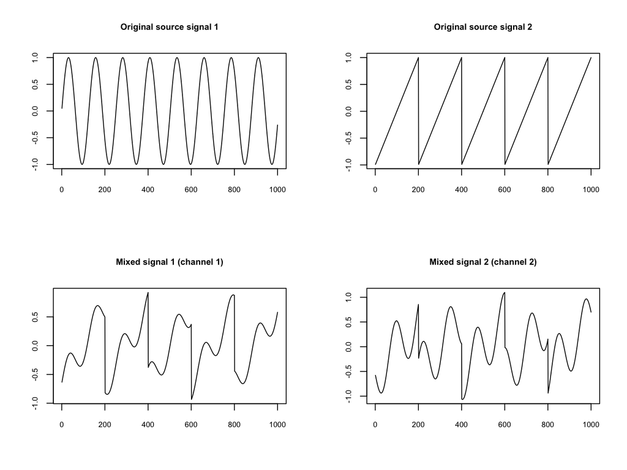

```r
par(mfrow = c(2, 2))
plot(1:1000, S[,1], type = "l", main = "Original source signal 1",
     xlab = "", ylab = "",
     cex.main = 0.8, cex.axis = 0.7)
plot(1:1000, S[,2], type = "l", main = "Original source signal 2",
     xlab = "", ylab = "",
     cex.main = 0.8, cex.axis = 0.7)
plot(1:1000, X[,1], type = "l", main = "Mixed signal 1 (channel 1)",
     xlab = "", ylab = "",
     cex.main = 0.8, cex.axis = 0.7)
plot(1:1000, X[,2], type = "l", main = "Mixed signal 2 (channel 2)",
     xlab = "", ylab = "",
     cex.main = 0.8, cex.axis = 0.7)
```

- ICA 모형 학습
  - `fastICA` 패키지의 `fastICA()` 함수를 이용

```r
library(fastICA)
a <- fastICA(X, 2)
```

- 학습 결과 확인

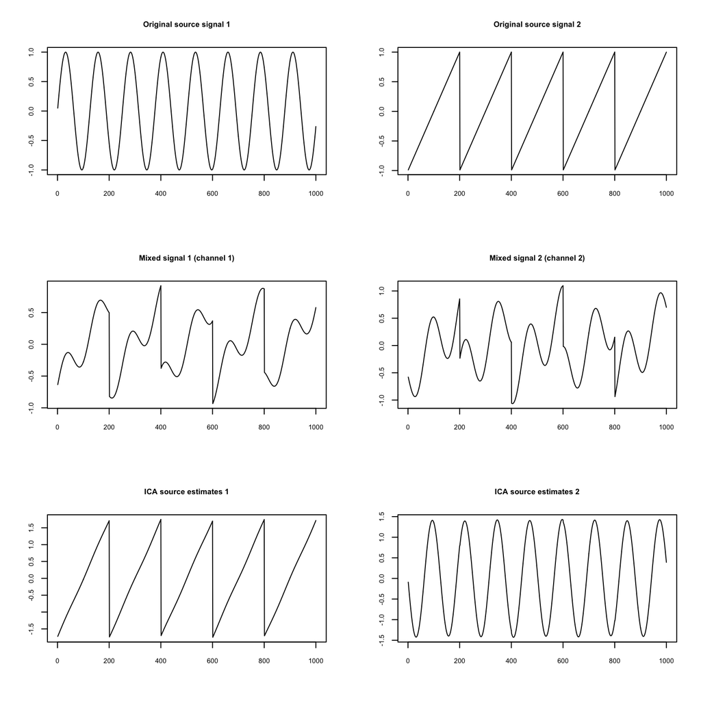

```r
par(mfrow = c(3, 2))
plot(1:1000, S[,1], type = "l", main = "Original source signal 1",
     xlab = "", ylab = "",
     cex.main = 0.8, cex.axis = 0.7)
plot(1:1000, S[,2], type = "l", main = "Original source signal 2",
     xlab = "", ylab = "",
     cex.main = 0.8, cex.axis = 0.7)
plot(1:1000, X[,1], type = "l", main = "Mixed signal 1 (channel 1)",
     xlab = "", ylab = "",
     cex.main = 0.8, cex.axis = 0.7)
plot(1:1000, X[,2], type = "l", main = "Mixed signal 2 (channel 2)",
     xlab = "", ylab = "",
     cex.main = 0.8, cex.axis = 0.7)
plot(1:1000, a$S[,1], type = "l", main = "ICA source estimates 1",
     xlab = "", ylab = "",
     cex.main = 0.8, cex.axis = 0.7)
plot(1:1000, a$S[,2], type = "l", main = "ICA source estimates 2",
     xlab = "", ylab = "",
     cex.main = 0.8, cex.axis = 0.7)
```

## 4. Multiple testing

- 동시에 여러 개의 가설을 검정하는 문제

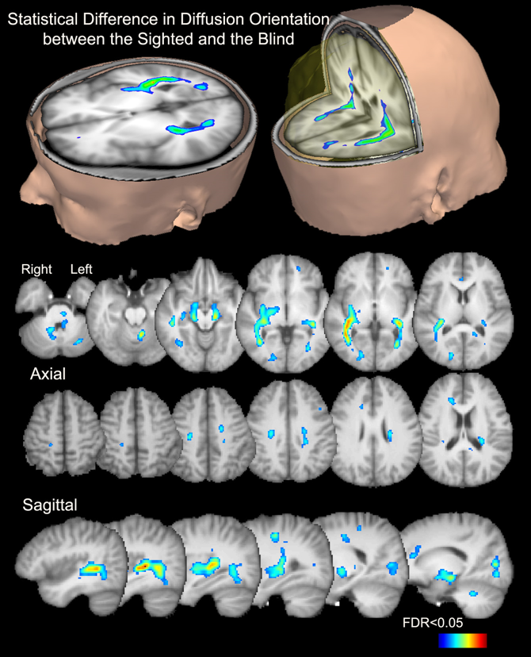

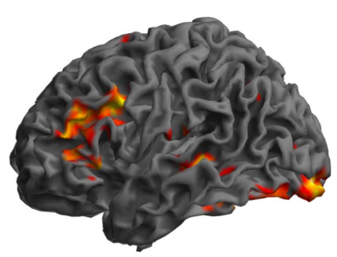

- 특이한 고객 발견, 이상 행동 발견, conversion rate에 영향을 주는 feature 발견 등에 활용 가능
- Hypotheses: $H_{0,1}, H_{0,2},...,H_{0,N}$
- Corresponding $z$-values: $z_1,...,z_N$
- Problem: $z_i$ 값에 적용할 threshold?
- Testing 결과

  | {} | Action: NULL | Action: NONNULL | Sum |
  | --- | --- | --- | --- |
  | Truth: NULL | $a$ | $b$ | $a + b$ |
  | Truth: NONNULL | $c$ | $d$ | $c + d$ |
  | Sum | $a + c$ | $b + d$ | $N = a+b+c+d$ |

- FWER vs. FDR
  - Familywise error rate: $P(b > 0)$을 기준치 이하로 제어
    - Bonferroni correction: 유의수준을 검정할 가설 갯수로 나눈 값을 사용, 즉 $\alpha' = \alpha/N$
    - Random field theory
  - FDR: $E(b/(b + d))$ 를 기준치 이하로 제어